# Recommender Systems: Practice Problem

Podcasts: build the user’s vector, retrieve, and update with feedback

Son Nguyen

# Practice Problem

## Practice Problem: Build the User’s Vector, Then Retrieve

A podcast app gives every podcast a 2-number embedding (number 1: news and business, number 2: comedy and stories). **These podcast embeddings were learned beforehand** by the app’s model from all users’ listening data, so in this problem they are **known**. Only the user’s embedding must be computed.

| Podcast | Embedding (news, comedy) |
| --- | --- |
| Podcast A | (0.8, 0.2) |
| Podcast B | (0.2, 0.9) |
| Podcast C | (0.6, 0.6) |
| Podcast D | (0.1, 0.4) |
| Podcast E | (0.9, 0.8) |
| Podcast F | (0.1, 1.2) |

Last month **the user** listened to **Podcast E** and **Podcast F**.

1. Compute **the user’s embedding** as the **average** of the podcasts they listened to.
2. Score every podcast with the **dot product**. Recommend the top 2 that the user has **not** heard.

**Method:** average-of-items user profile (Rocchio’s method; YouTube’s 2016 system started this way) + dot-product retrieval of the top K.

**Caveat:** on its own, this is a baseline, not what YouTube runs today. Big systems replace the plain average with a neural network (two-tower or transformer). The retrieval step after it (dot product, top K) is exactly what they still do.

## Solution (a) and (b): The User’s Vector and Top 2 (Click to Step Through)

| Podcast | (news, comedy) | Weight |
| --- | --- | --- |
| A | (0.8, 0.2) |  |
| B | (0.2, 0.9) |  |
| C | (0.6, 0.6) |  |
| D | (0.1, 0.4) |  |
| E | (0.9, 0.8) | **1** (heard) |
| F | (0.1, 1.2) | **1** (heard) |

**The user = average of the 2 they heard:**

$$\begin{aligned}\mathbf{u} &= \dfrac{(0.9, 0.8) + (0.1, 1.2)}{2} \\ &= \dfrac{(1.0,\ 2.0)}{2} = (0.5,\ 1)\end{aligned}$$

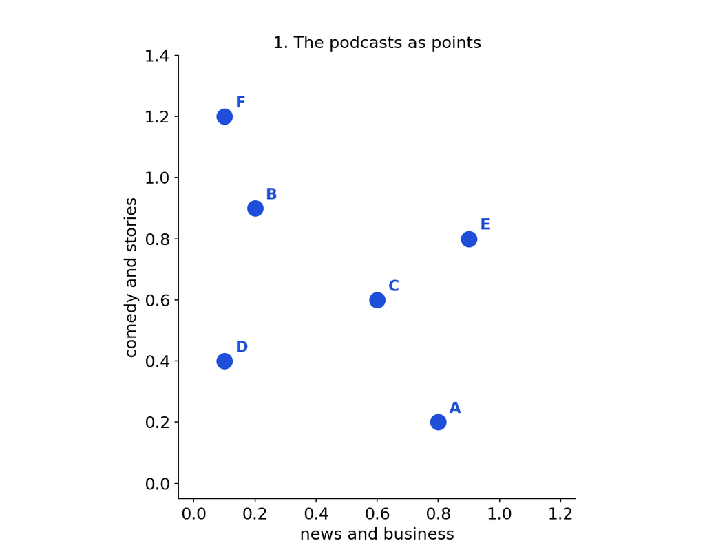

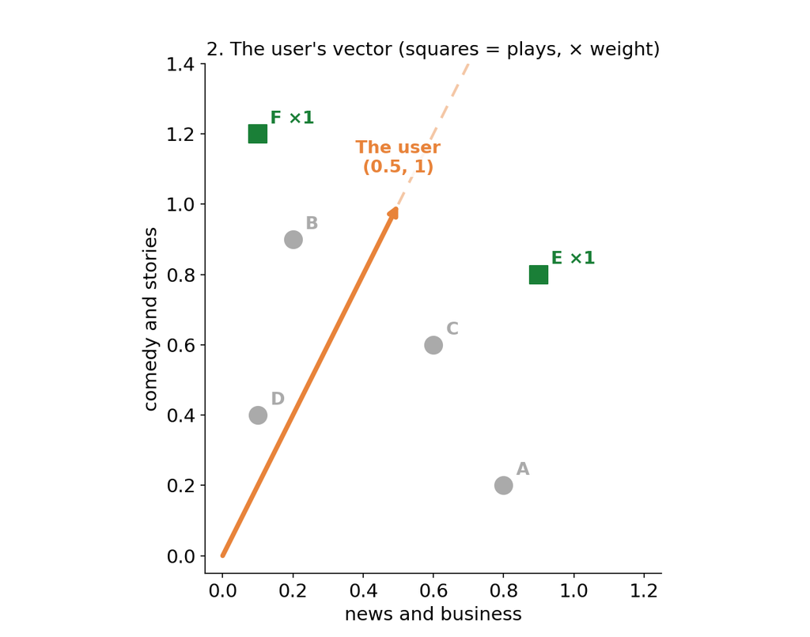

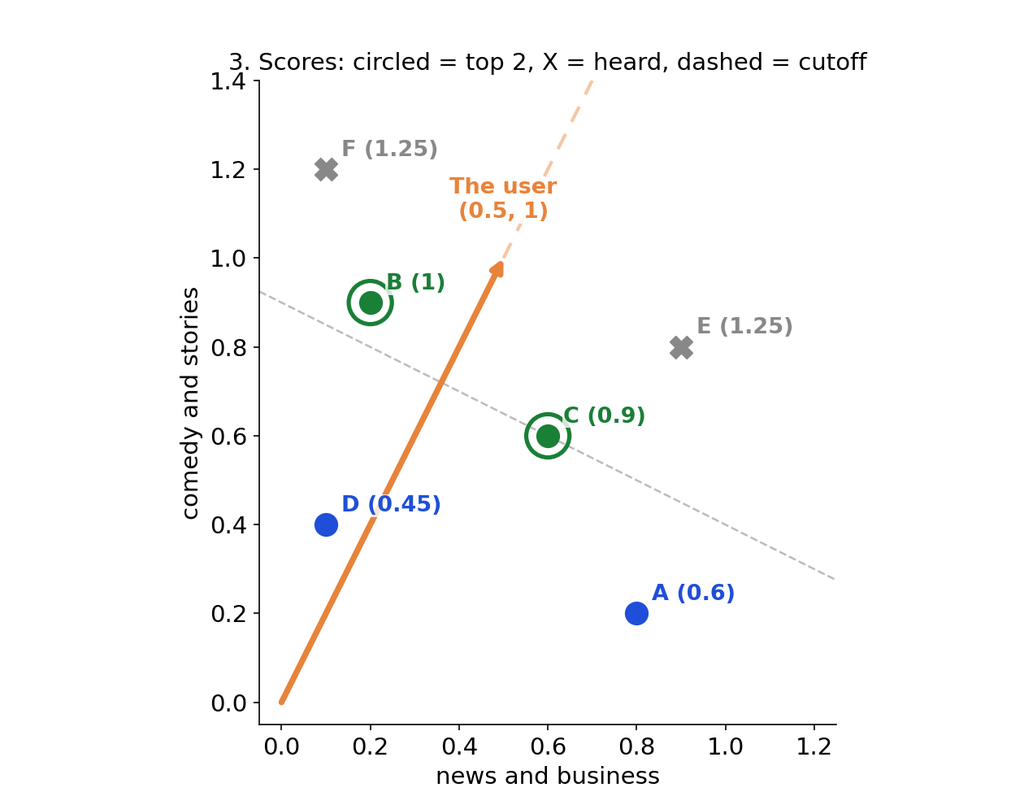

$\text{score} = 0.5 \times \text{news} + 1 \times \text{comedy}$

| Podcast | Calculation | Score | Rank |
| --- | --- | --- | --- |
| E | 0.5(0.9) + 1(0.8) | 1.25 | heard: skip |
| F | 0.5(0.1) + 1(1.2) | 1.25 | heard: skip |
| **B** | 0.5(0.2) + 1(0.9) | 1 | **#1 ✓** |
| **C** | 0.5(0.6) + 1(0.6) | 0.9 | **#2 ✓** |
| A | 0.5(0.8) + 1(0.2) | 0.6 | #3 |
| D | 0.5(0.1) + 1(0.4) | 0.45 | #4 |

**Recommend: B and C.** (E and F score higher, but the user already heard them.)

## Practice Problem, Round 2: One Week Later

| New this week | Embedding (also learned beforehand) |
| --- | --- |
| Podcast G | (1.0, 0.5) |
| Podcast H | (0.1, 1.0) |
| Podcast I | (0.7, 0.9) |

The user played **Podcast C** (one of our picks) and **Podcast D** (which we did not recommend); they skipped Podcast B. Three **new** podcasts (G, H, I) were also released this week.

3. Recompute the user’s embedding as a **weighted average** of their 4 plays: older plays (E, F) count **1**, this week’s plays (C, D) count **2**. Score the 5 podcasts they have not heard (A, B, G, H, I) and recommend the top 2.
4. The user also gave **feedback**: they **liked** Podcast D and tapped **“not interested”** on Podcast C. The app doubles the weight of a liked play and gives a “not interested” play weight **−1**. Recompute their embedding and their top 2.

## Solution (c): Recent Plays Count More (Click to Step Through)

| Podcast | (news, comedy) | Weight |
| --- | --- | --- |
| A | (0.8, 0.2) |  |
| B | (0.2, 0.9) |  |
| C | (0.6, 0.6) | **2** (this week) |
| D | (0.1, 0.4) | **2** (this week) |
| E | (0.9, 0.8) | **1** (older) |
| F | (0.1, 1.2) | **1** (older) |
| G | (1.0, 0.5) | new |
| H | (0.1, 1.0) | new |
| I | (0.7, 0.9) | new |

**The user = weighted average.** Weights: E ×1, F ×1, C ×2, D ×2; total = 6.

$$\begin{aligned}\mathbf{u} &= \dfrac{(0.9, 0.8) + (0.1, 1.2) + 2(0.6, 0.6) + 2(0.1, 0.4)}{6} \\ &= \dfrac{(2.4,\ 4.0)}{6} = (0.4,\ 0.667)\end{aligned}$$

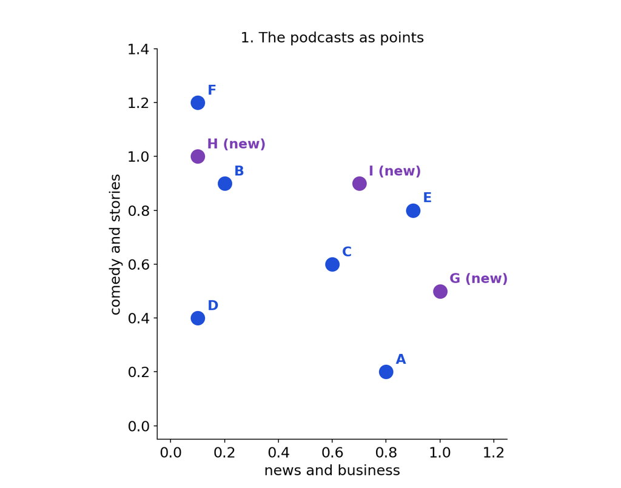

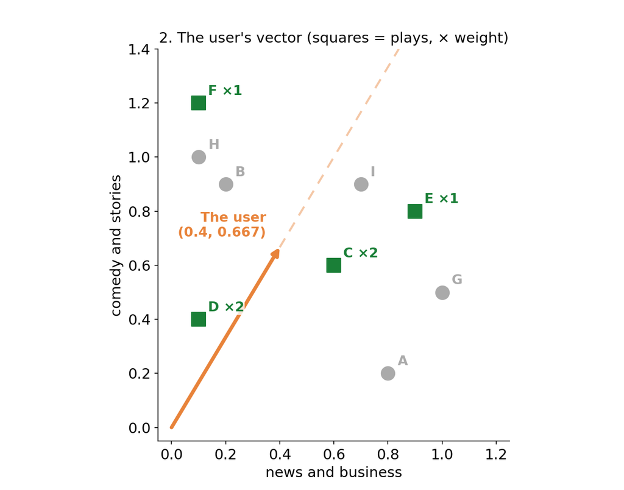

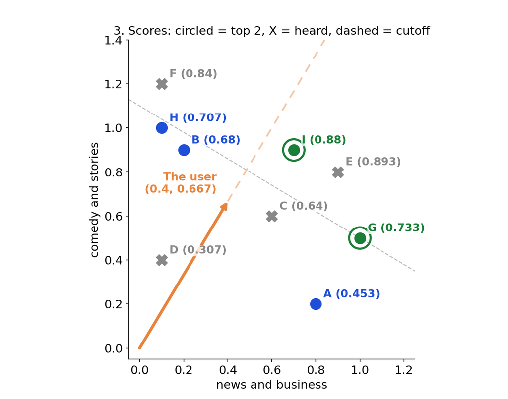

$\text{score} = 0.4 \times \text{news} + 0.667 \times \text{comedy}$

| Podcast | Calculation | Score | Rank |
| --- | --- | --- | --- |
| E | 0.4(0.9) + 0.667(0.8) | 0.893 | heard: skip |
| **I** | 0.4(0.7) + 0.667(0.9) | 0.88 | **#1 ✓** |
| F | 0.4(0.1) + 0.667(1.2) | 0.84 | heard: skip |
| **G** | 0.4(1) + 0.667(0.5) | 0.733 | **#2 ✓** |
| H | 0.4(0.1) + 0.667(1) | 0.707 | #3 |
| B | 0.4(0.2) + 0.667(0.9) | 0.68 | #4 |
| C | 0.4(0.6) + 0.667(0.6) | 0.64 | heard: skip |
| A | 0.4(0.8) + 0.667(0.2) | 0.453 | #5 |
| D | 0.4(0.1) + 0.667(0.4) | 0.307 | heard: skip |

**Recommend: I and G.** The user’s vector moved toward C and D, their newest plays.

## Solution (d): Feedback Changes the Weights (Click to Step Through)

| Podcast | (news, comedy) | Weight |
| --- | --- | --- |
| A | (0.8, 0.2) |  |
| B | (0.2, 0.9) |  |
| C | (0.6, 0.6) | **(−1)** (not interested) |
| D | (0.1, 0.4) | **4** (this week, liked) |
| E | (0.9, 0.8) | **1** (older) |
| F | (0.1, 1.2) | **1** (older) |
| G | (1.0, 0.5) | new |
| H | (0.1, 1.0) | new |
| I | (0.7, 0.9) | new |

**The user = weighted average.** Weights: E ×1, F ×1, C ×(−1), D ×4; total = 5.

$$\begin{aligned}\mathbf{u} &= \dfrac{(0.9, 0.8) + (0.1, 1.2) - (0.6, 0.6) + 4(0.1, 0.4)}{5} \\ &= \dfrac{(0.8,\ 3.0)}{5} = (0.16,\ 0.6)\end{aligned}$$

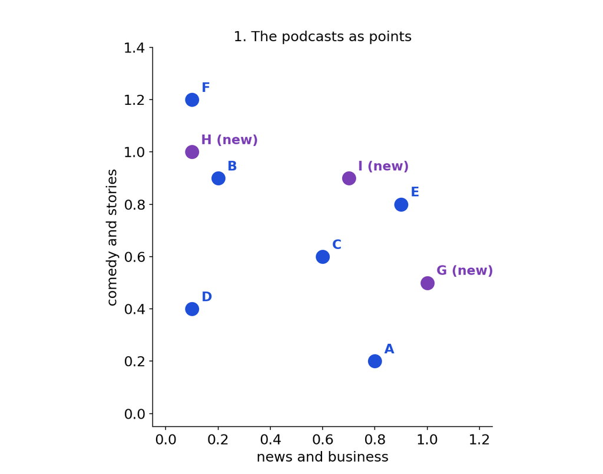

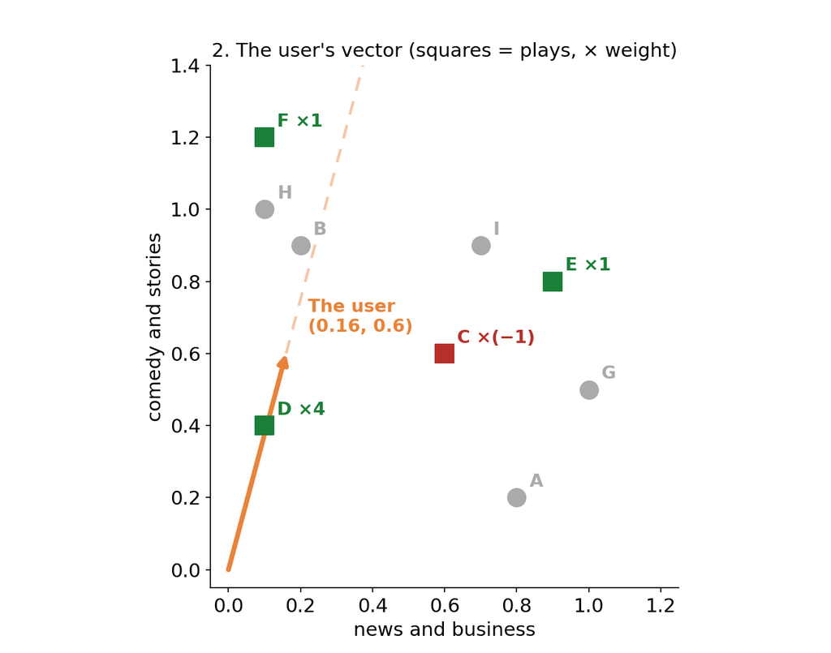

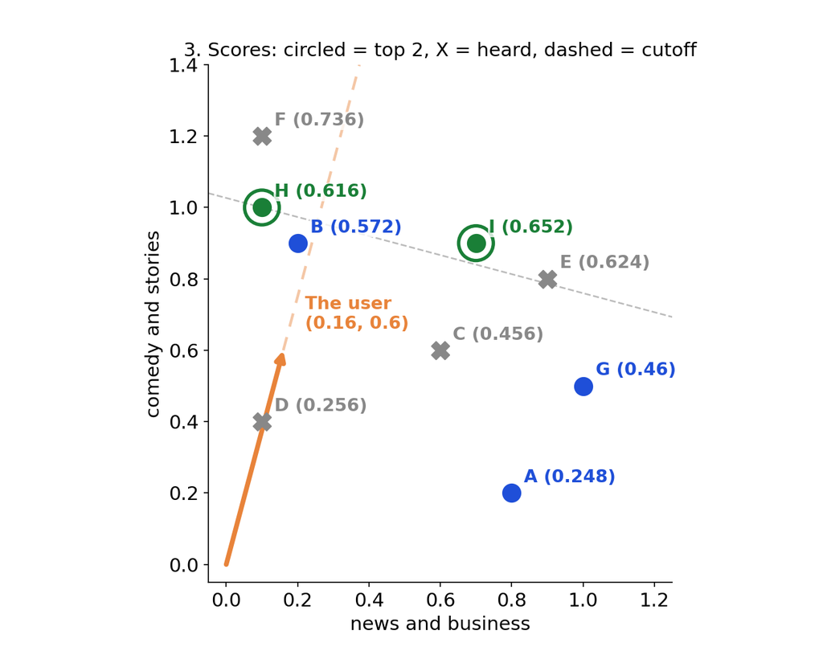

$\text{score} = 0.16 \times \text{news} + 0.6 \times \text{comedy}$

| Podcast | Calculation | Score | Rank |
| --- | --- | --- | --- |
| F | 0.16(0.1) + 0.6(1.2) | 0.736 | heard: skip |
| **I** | 0.16(0.7) + 0.6(0.9) | 0.652 | **#1 ✓** |
| E | 0.16(0.9) + 0.6(0.8) | 0.624 | heard: skip |
| **H** | 0.16(0.1) + 0.6(1) | 0.616 | **#2 ✓** |
| B | 0.16(0.2) + 0.6(0.9) | 0.572 | #3 |
| G | 0.16(1) + 0.6(0.5) | 0.46 | #4 |
| C | 0.16(0.6) + 0.6(0.6) | 0.456 | heard: skip |
| D | 0.16(0.1) + 0.6(0.4) | 0.256 | heard: skip |
| A | 0.16(0.8) + 0.6(0.2) | 0.248 | #5 |

**Recommend: I and H.** Feedback swapped G (news) for H (stories): the user rejected C and liked D.

## The User’s Embedding Over Time (Click to Step Through)

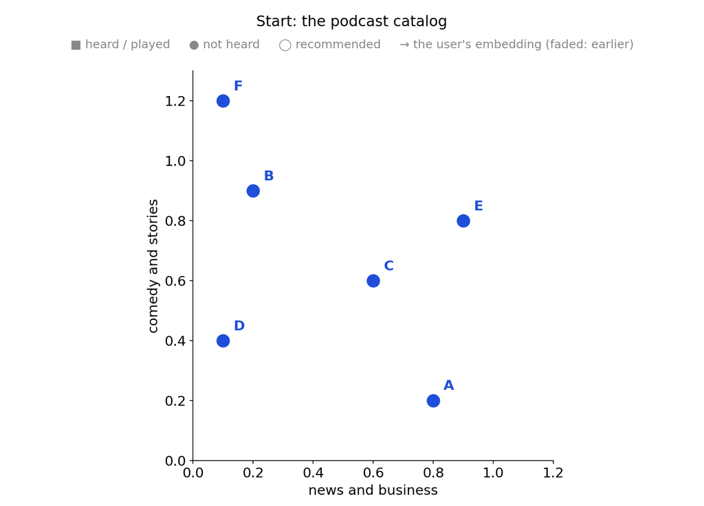

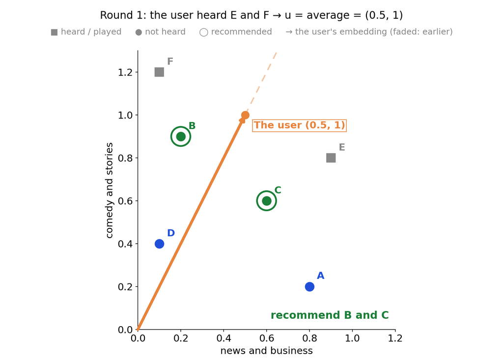

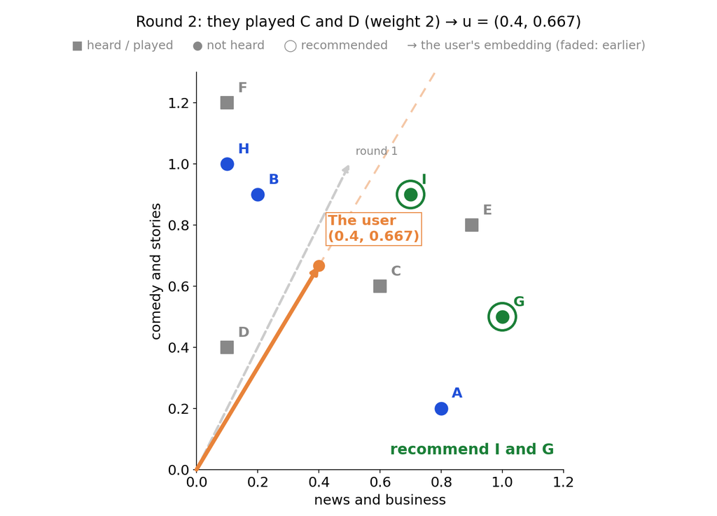

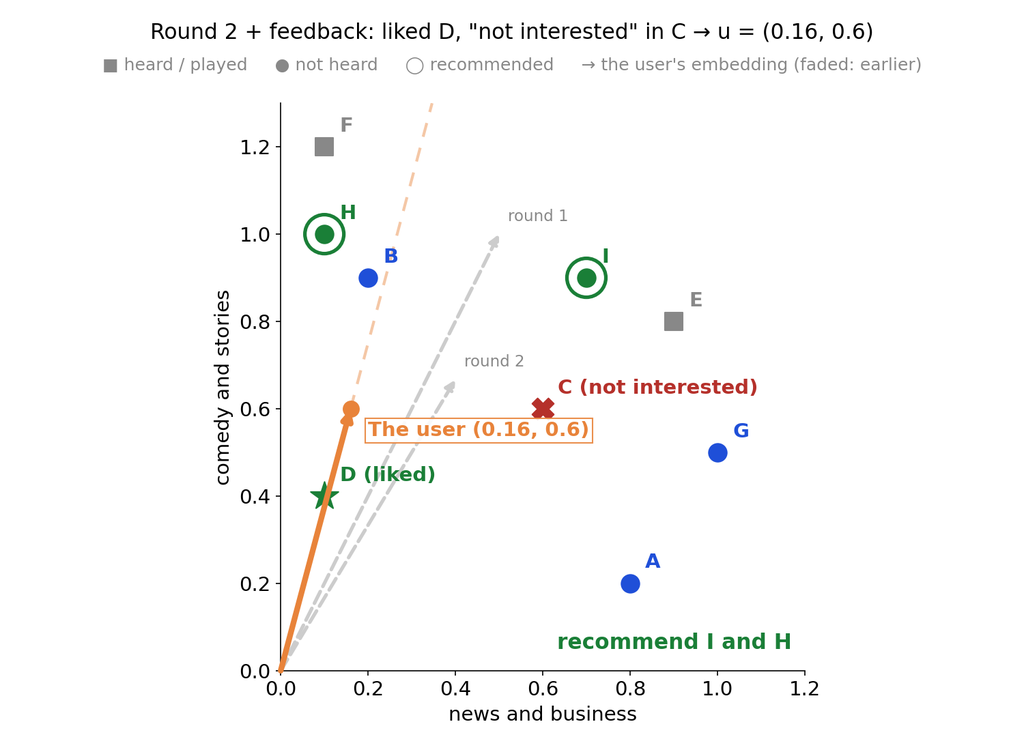